# Global Preferences Survey

Additional work

Author

Sara Cerioli

Published

February 13, 2023

```r
# Set the path
knitr::opts_knit$set(root.dir = "C:/Users/ceriosar/OneDrive - Mars Inc/Desktop/Private Sara/Global-Preferences-Survey/")
```

# 0. Introduction

Interesting ideas to explore:

- Interaction effects between Log GDP and GEI
- Use another economic development indicator (such as GINI index)
- Split the HDI sub-indexes to understand which contributes more

# 1. Interaction effects between LogGDP p/c and Gender Equality Indexes

## 1.1 Using the Gender Equality Index (GEI) from the original authors

```r
# (This will be needed for later)
GDI_index <- CreateGDIindex()
# Load and prepare the data
data_all <- LoadData()
data_all$GDI_index <- GDI_index
data_all <- PrepareData_new(data_all)
data_all$data <- Standardize(data    = data_all$data,
                             columns = c(5:10),
                             level   = "country")
dataComplete <- data_all$data[complete.cases(data_all$data)]

# Create the models
models <- CreateModelsForPreferencesCountryLevel(dataComplete, robust = FALSE)
dataCoeff <- SummaryCoeffPerPreferencePerCountry(models)
dataCoeff[data_all$data, `:=` (isocode     = i.isocode,
                               logAvgGDPpc = log(i.avgGDPpc)),
          on = "country"]
setnames(dataCoeff, old = "gender1", new = "gender")

# PCA on the preferences
summaryIndex <- AvgGenderDiffPreferencesPCA(dataCoeff)
summaryIndex <- CreateSummaryIndex_new(summaryIndex, data_all)
summaryIndex$GenderIndex <- GenderIndexPCA(summaryIndex[, c(5:8)])
summaryIndex <- Standardize(data    = summaryIndex,
                            columns = c(2, 4:9, 14),
                            newName = TRUE)
summaryIndex[, GenderIndexRescaled := Rescale(GenderIndex)]

# Gender Inequality Index of UNDP has opposite meaning, so let's invert it
summaryIndex[, ValueUNStd := -ValueUNStd]
```

When creating the models, we can also have a look at their summary and then perform an Analysis Of the Variance (ANOVA) to understand if they are relevant terms to be added to the model:

```r
# Create the simple linear model
lr <- lm(avgGenderDiffStd ~ logAvgGDPpcStd + GenderIndexStd,
         data = summaryIndex)
cat("Multilinear Regression Model with no interaction effects\n--------------------------------------------------------")
```

```
Multilinear Regression Model with no interaction effects
--------------------------------------------------------
```

```r
summary(lr)
```

```
Call:
lm(formula = avgGenderDiffStd ~ logAvgGDPpcStd + GenderIndexStd,
    data = summaryIndex)

Residuals:
     Min       1Q   Median       3Q      Max
-1.21391 -0.50117 -0.05373  0.54229  1.43217

Coefficients:
                 Estimate Std. Error t value Pr(>|t|)
(Intercept)    -7.205e-17  7.836e-02   0.000 1.000000
logAvgGDPpcStd  5.003e-01  9.401e-02   5.322 1.08e-06 ***
GenderIndexStd  3.358e-01  9.401e-02   3.572 0.000632 ***
---
Signif. codes:  0 '***' 0.001 '**' 0.01 '*' 0.05 '.' 0.1 ' ' 1

Residual standard error: 0.6831 on 73 degrees of freedom
Multiple R-squared:  0.5458,    Adjusted R-squared:  0.5334
F-statistic: 43.86 on 2 and 73 DF,  p-value: 3.082e-13
```

```r
# Create the linear model with interaction effects
lri <- lm(avgGenderDiffStd ~ logAvgGDPpcStd * GenderIndexStd,
          data = summaryIndex)
cat("Multilinear Regression Model with interaction effects\n-----------------------------------------------------")
```

```
Multilinear Regression Model with interaction effects
-----------------------------------------------------
```

```r
summary(lri)
```

```
Call:
lm(formula = avgGenderDiffStd ~ logAvgGDPpcStd * GenderIndexStd,
    data = summaryIndex)

Residuals:
    Min      1Q  Median      3Q     Max
-1.1089 -0.4955 -0.0497  0.4105  1.4475

Coefficients:
                              Estimate Std. Error t value Pr(>|t|)
(Intercept)                   -0.10879    0.08703  -1.250 0.215323
logAvgGDPpcStd                 0.47204    0.09141   5.164 2.07e-06 ***
GenderIndexStd                 0.33449    0.09072   3.687 0.000437 ***
logAvgGDPpcStd:GenderIndexStd  0.20264    0.08023   2.526 0.013748 *
---
Signif. codes:  0 '***' 0.001 '**' 0.01 '*' 0.05 '.' 0.1 ' ' 1

Residual standard error: 0.6592 on 72 degrees of freedom
Multiple R-squared:  0.5828,    Adjusted R-squared:  0.5654
F-statistic: 33.52 on 3 and 72 DF,  p-value: 1.135e-13
```

```r
# This here is just for plotting purposes
lri_b <- lm(avgGenderDiffStd ~ GenderIndexStd * logAvgGDPpcStd,
            data = summaryIndex)

# ANOVA
cat("ANALYSIS OF VARIANCE\n--------------------")
```

```
ANALYSIS OF VARIANCE
--------------------
```

```r
anova(lr, lri)
```

```
Analysis of Variance Table

Model 1: avgGenderDiffStd ~ logAvgGDPpcStd + GenderIndexStd
Model 2: avgGenderDiffStd ~ logAvgGDPpcStd * GenderIndexStd
  Res.Df    RSS Df Sum of Sq      F  Pr(>F)
1     73 34.063
2     72 31.291  1    2.7723 6.3791 0.01375 *
---
Signif. codes:  0 '***' 0.001 '**' 0.01 '*' 0.05 '.' 0.1 ' ' 1
```

From this, we see that interaction effect needs to be included. In order to understand better the effects, we can plot them:

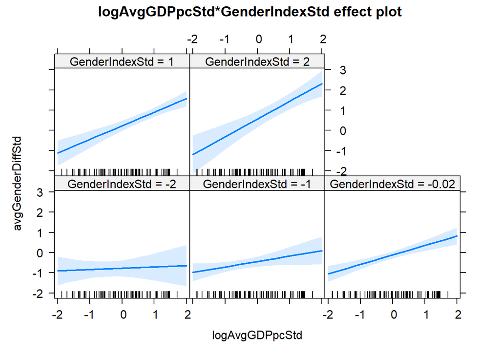

```r
plot(effect(term = "logAvgGDPpcStd:GenderIndexStd", mod = lri))
```

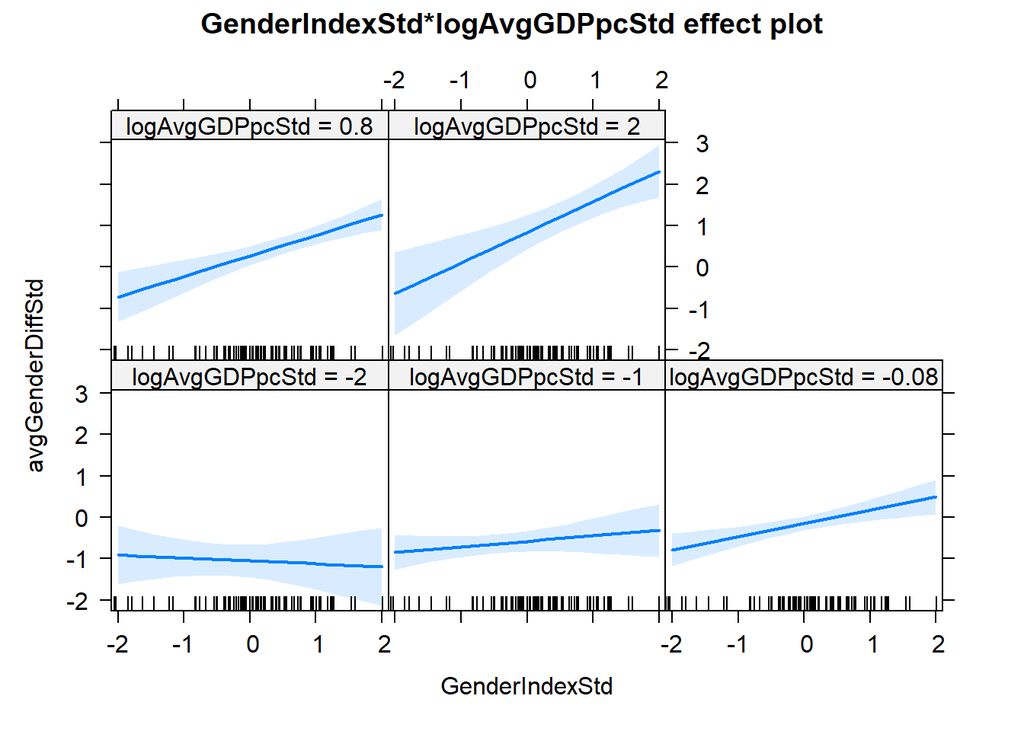

```r
plot(effect(term = "GenderIndexStd:logAvgGDPpcStd", mod = lri_b))
```

The effect of the economic development increases with the increase of the GEI and vice-versa, with low economic development the effect of the GEI on the gender differences is lost, while it starts to have an effect for more economically developed countries.

## 1.2 Using the GDI from UNDP

```r
lr2 <- lm(avgGenderDiffStd ~ logAvgGDPpcStd + GDIStd, data = summaryIndex)
cat("Multilinear Regression Model with no interaction effects\n--------------------------------------------------------")
```

```
Multilinear Regression Model with no interaction effects
--------------------------------------------------------
```

```r
summary(lr2)
```

```
Call:
lm(formula = avgGenderDiffStd ~ logAvgGDPpcStd + GDIStd, data = summaryIndex)

Residuals:
     Min       1Q   Median       3Q      Max
-1.63959 -0.57292 -0.04957  0.64562  1.46440

Coefficients:
                 Estimate Std. Error t value Pr(>|t|)
(Intercept)    -9.238e-17  8.429e-02   0.000    1.000
logAvgGDPpcStd  6.271e-01  1.002e-01   6.259 2.38e-08 ***
GDIStd          1.052e-01  1.002e-01   1.050    0.297
---
Signif. codes:  0 '***' 0.001 '**' 0.01 '*' 0.05 '.' 0.1 ' ' 1

Residual standard error: 0.7349 on 73 degrees of freedom
Multiple R-squared:  0.4744,    Adjusted R-squared:   0.46
F-statistic: 32.94 on 2 and 73 DF,  p-value: 6.376e-11
```

```r
# Create the linear model with interaction effects
lri2 <- lm(avgGenderDiffStd ~ logAvgGDPpcStd * GDIStd,
           data = summaryIndex)
cat("Multilinear Regression Model with interaction effects\n-----------------------------------------------------")
```

```
Multilinear Regression Model with interaction effects
-----------------------------------------------------
```

```r
summary(lri2)
```

```
Call:
lm(formula = avgGenderDiffStd ~ logAvgGDPpcStd * GDIStd, data = summaryIndex)

Residuals:
     Min       1Q   Median       3Q      Max
-1.56770 -0.54914  0.00916  0.58318  1.54158

Coefficients:
                      Estimate Std. Error t value Pr(>|t|)
(Intercept)           -0.11989    0.09841  -1.218   0.2271
logAvgGDPpcStd         0.57360    0.10056   5.704 2.42e-07 ***
GDIStd                 0.31384    0.13577   2.312   0.0237 *
logAvgGDPpcStd:GDIStd  0.22855    0.10334   2.212   0.0302 *
---
Signif. codes:  0 '***' 0.001 '**' 0.01 '*' 0.05 '.' 0.1 ' ' 1

Residual standard error: 0.716 on 72 degrees of freedom
Multiple R-squared:  0.5078,    Adjusted R-squared:  0.4873
F-statistic: 24.76 on 3 and 72 DF,  p-value: 4.076e-11
```

```r
# This here is just for plotting purposes
lri2_b <- lm(avgGenderDiffStd ~ GDIStd * logAvgGDPpcStd,
             data = summaryIndex)

# ANOVA
cat("ANALYSIS OF VARIANCE\n--------------------")
```

```
ANALYSIS OF VARIANCE
--------------------
```

```r
anova(lr2, lri2)
```

```
Analysis of Variance Table

Model 1: avgGenderDiffStd ~ logAvgGDPpcStd + GDIStd
Model 2: avgGenderDiffStd ~ logAvgGDPpcStd * GDIStd
  Res.Df    RSS Df Sum of Sq      F  Pr(>F)
1     73 39.422
2     72 36.914  1    2.5075 4.8908 0.03018 *
---
Signif. codes:  0 '***' 0.001 '**' 0.01 '*' 0.05 '.' 0.1 ' ' 1
```

Plotting the effects:

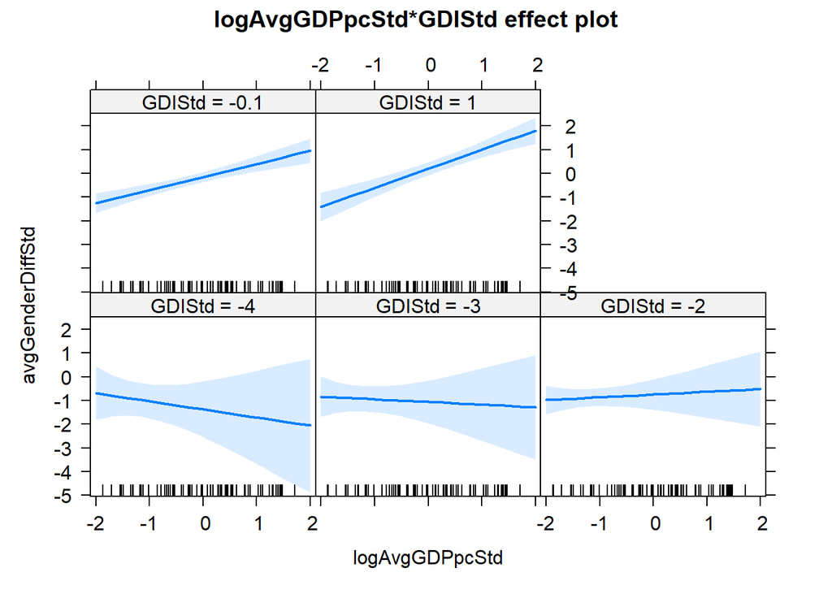

```r
plot(effect(term = "logAvgGDPpcStd:GDIStd", mod = lri2))
```

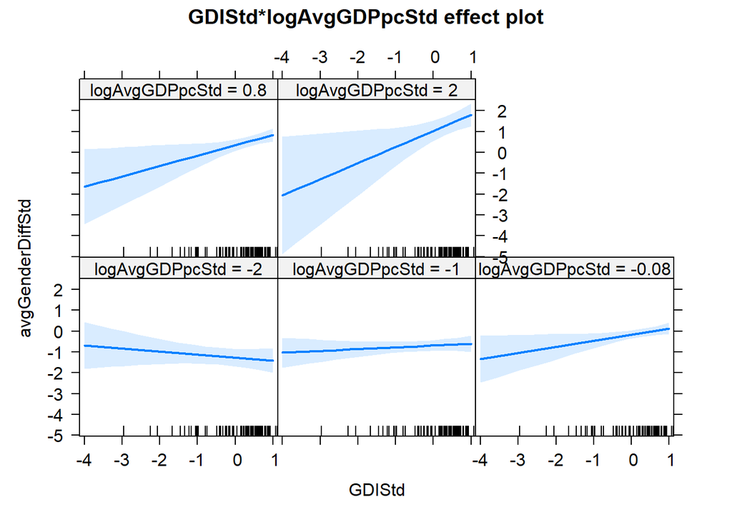

```r
plot(effect(term = "GDIStd:logAvgGDPpcStd", mod = lri2_b))
```

## 1.3 Using the GGGI from WEF

```r
lr3 <- lm(avgGenderDiffStd ~ logAvgGDPpcStd + ScoreWEFStd,
          data = summaryIndex)
cat("Multilinear Regression Model with no interaction effects\n--------------------------------------------------------")
```

```
Multilinear Regression Model with no interaction effects
--------------------------------------------------------
```

```r
summary(lr3)
```

```
Call:
lm(formula = avgGenderDiffStd ~ logAvgGDPpcStd + ScoreWEFStd,
    data = summaryIndex)

Residuals:
     Min       1Q   Median       3Q      Max
-1.39470 -0.49586 -0.01756  0.59312  1.22628

Coefficients:
               Estimate Std. Error t value Pr(>|t|)
(Intercept)     0.02398    0.08221   0.292   0.7714
logAvgGDPpcStd  0.61993    0.08781   7.060 1.04e-09 ***
ScoreWEFStd     0.22341    0.08643   2.585   0.0119 *
---
Signif. codes:  0 '***' 0.001 '**' 0.01 '*' 0.05 '.' 0.1 ' ' 1

Residual standard error: 0.6964 on 69 degrees of freedom
  (4 Beobachtungen als fehlend gelöscht)
Multiple R-squared:  0.5158,    Adjusted R-squared:  0.5018
F-statistic: 36.75 on 2 and 69 DF,  p-value: 1.361e-11
```

```r
# Create the linear model with interaction effects
lri3 <- lm(avgGenderDiffStd ~ logAvgGDPpcStd * ScoreWEFStd,
           data = summaryIndex)
cat("Multilinear Regression Model with interaction effects\n-----------------------------------------------------")
```

```
Multilinear Regression Model with interaction effects
-----------------------------------------------------
```

```r
summary(lri3)
```

```
Call:
lm(formula = avgGenderDiffStd ~ logAvgGDPpcStd * ScoreWEFStd,
    data = summaryIndex)

Residuals:
     Min       1Q   Median       3Q      Max
-1.08354 -0.54643 -0.03217  0.56394  1.34153

Coefficients:
                           Estimate Std. Error t value Pr(>|t|)
(Intercept)                -0.01625    0.08376  -0.194   0.8467
logAvgGDPpcStd              0.57698    0.08946   6.450 1.37e-08 ***
ScoreWEFStd                 0.21540    0.08510   2.531   0.0137 *
logAvgGDPpcStd:ScoreWEFStd  0.14992    0.08173   1.834   0.0710 .
---
Signif. codes:  0 '***' 0.001 '**' 0.01 '*' 0.05 '.' 0.1 ' ' 1

Residual standard error: 0.6847 on 68 degrees of freedom
  (4 Beobachtungen als fehlend gelöscht)
Multiple R-squared:  0.5386,    Adjusted R-squared:  0.5183
F-statistic: 26.46 on 3 and 68 DF,  p-value: 1.87e-11
```

```r
# This here is just for plotting purposes
lri3_b <- lm(avgGenderDiffStd ~ ScoreWEFStd * logAvgGDPpcStd,
             data = summaryIndex)

# ANOVA
cat("ANALYSIS OF VARIANCE\n--------------------")
```

```
ANALYSIS OF VARIANCE
--------------------
```

```r
anova(lr3, lri3)
```

```
Analysis of Variance Table

Model 1: avgGenderDiffStd ~ logAvgGDPpcStd + ScoreWEFStd
Model 2: avgGenderDiffStd ~ logAvgGDPpcStd * ScoreWEFStd
  Res.Df    RSS Df Sum of Sq     F  Pr(>F)
1     69 33.461
2     68 31.884  1    1.5777 3.365 0.07097 .
---
Signif. codes:  0 '***' 0.001 '**' 0.01 '*' 0.05 '.' 0.1 ' ' 1
```

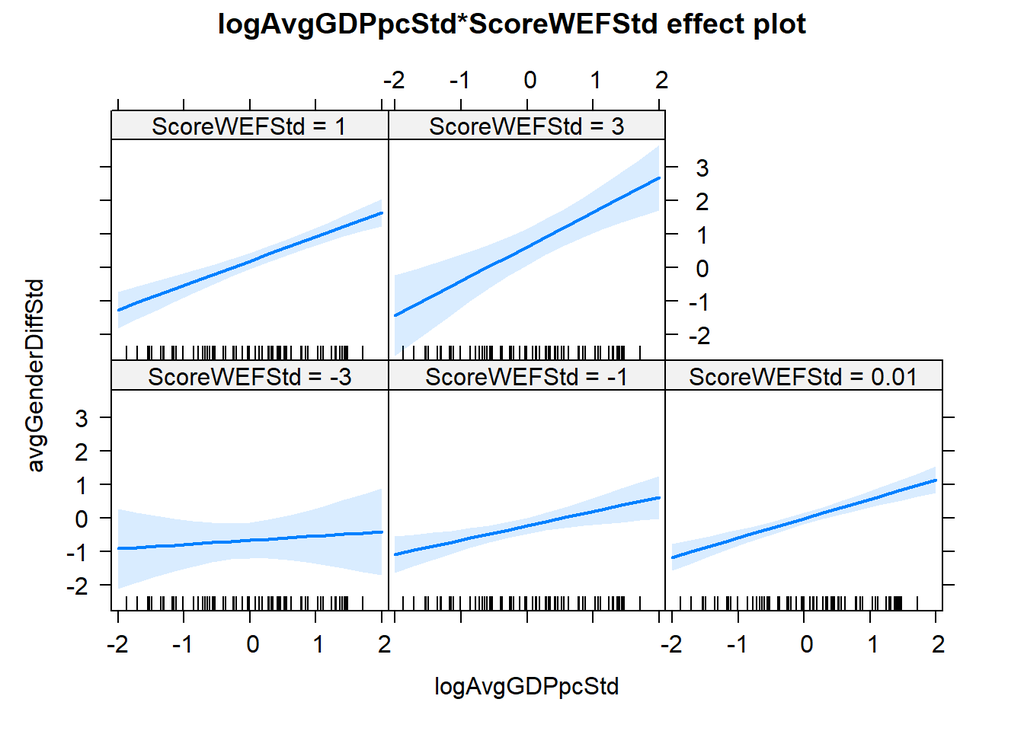

```r
plot(effect(term = "logAvgGDPpcStd:ScoreWEFStd", mod = lri3))
```

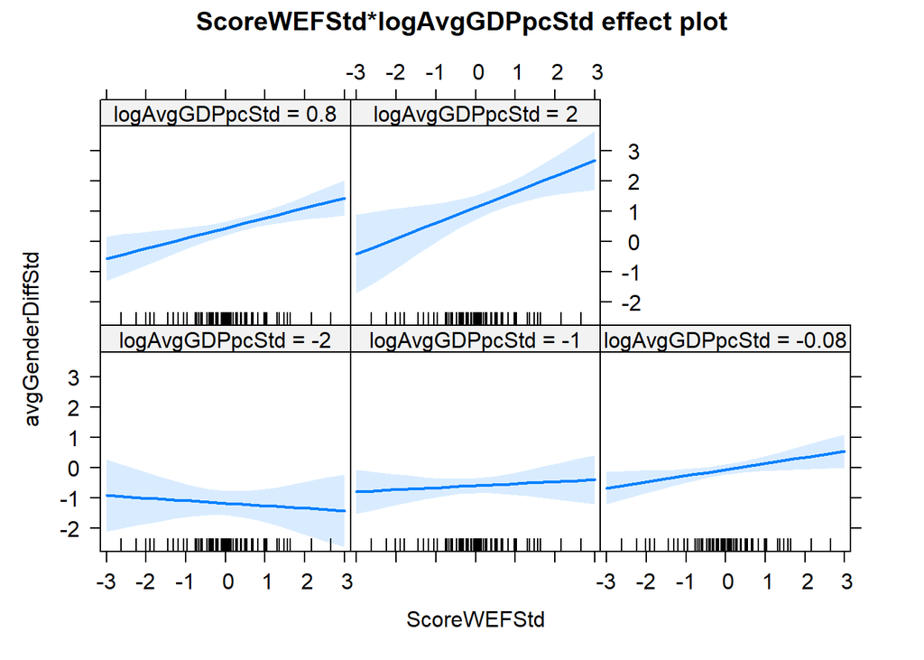

```r
plot(effect(term = "ScoreWEFStd:logAvgGDPpcStd", mod = lri3_b))
```

## 1.4 Using the GII from UNDP

```r
lr4 <- lm(avgGenderDiffStd ~ logAvgGDPpcStd + ValueUNStd,
          data = summaryIndex)
cat("Multilinear Regression Model with no interaction effects\n--------------------------------------------------------")
```

```
Multilinear Regression Model with no interaction effects
--------------------------------------------------------
```

```r
summary(lr4)
```

```
Call:
lm(formula = avgGenderDiffStd ~ logAvgGDPpcStd + ValueUNStd,
    data = summaryIndex)

Residuals:
     Min       1Q   Median       3Q      Max
-1.48672 -0.63228 -0.03013  0.62101  1.48048

Coefficients:
               Estimate Std. Error t value Pr(>|t|)
(Intercept)    0.001914   0.083891   0.023    0.982
logAvgGDPpcStd 0.412726   0.161958   2.548    0.013 *
ValueUNStd     0.318040   0.162378   1.959    0.054 .
---
Signif. codes:  0 '***' 0.001 '**' 0.01 '*' 0.05 '.' 0.1 ' ' 1

Residual standard error: 0.7264 on 72 degrees of freedom
  (1 Beobachtung als fehlend gelöscht)
Multiple R-squared:  0.492, Adjusted R-squared:  0.4779
F-statistic: 34.87 on 2 and 72 DF,  p-value: 2.575e-11
```

```r
# Create the linear model with interaction effects
lri4 <- lm(avgGenderDiffStd ~ logAvgGDPpcStd * ValueUNStd,
           data = summaryIndex)
cat("Multilinear Regression Model with interaction effects\n-----------------------------------------------------")
```

```
Multilinear Regression Model with interaction effects
-----------------------------------------------------
```

```r
summary(lri4)
```

```
Call:
lm(formula = avgGenderDiffStd ~ logAvgGDPpcStd * ValueUNStd,
    data = summaryIndex)

Residuals:
     Min       1Q   Median       3Q      Max
-1.48318 -0.50627 -0.02048  0.52104  1.52103

Coefficients:
                          Estimate Std. Error t value Pr(>|t|)
(Intercept)               -0.13377    0.11403  -1.173  0.24464
logAvgGDPpcStd             0.42804    0.16001   2.675  0.00927 **
ValueUNStd                 0.30335    0.16040   1.891  0.06268 .
logAvgGDPpcStd:ValueUNStd  0.16040    0.09273   1.730  0.08803 .
---
Signif. codes:  0 '***' 0.001 '**' 0.01 '*' 0.05 '.' 0.1 ' ' 1

Residual standard error: 0.7165 on 71 degrees of freedom
  (1 Beobachtung als fehlend gelöscht)
Multiple R-squared:  0.5125,    Adjusted R-squared:  0.492
F-statistic: 24.89 on 3 and 71 DF,  p-value: 4.112e-11
```

```r
# This here is just for plotting purposes
lri4_b <- lm(avgGenderDiffStd ~ ValueUNStd * logAvgGDPpcStd,
             data = summaryIndex)

# ANOVA
cat("ANALYSIS OF VARIANCE\n--------------------")
```

```
ANALYSIS OF VARIANCE
--------------------
```

```r
anova(lr4, lri4)
```

```
Analysis of Variance Table

Model 1: avgGenderDiffStd ~ logAvgGDPpcStd + ValueUNStd
Model 2: avgGenderDiffStd ~ logAvgGDPpcStd * ValueUNStd
  Res.Df    RSS Df Sum of Sq      F  Pr(>F)
1     72 37.988
2     71 36.452  1    1.5361 2.9919 0.08803 .
---
Signif. codes:  0 '***' 0.001 '**' 0.01 '*' 0.05 '.' 0.1 ' ' 1
```

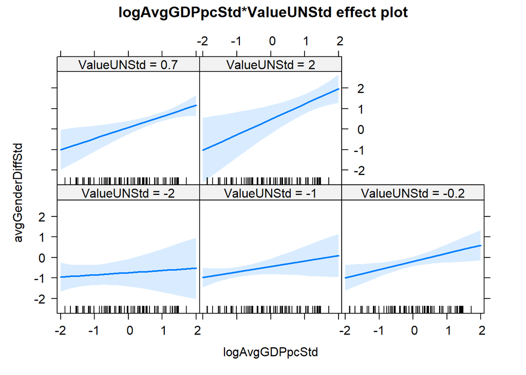

```r
plot(effect(term = "logAvgGDPpcStd:ValueUNStd", mod = lri4))
```

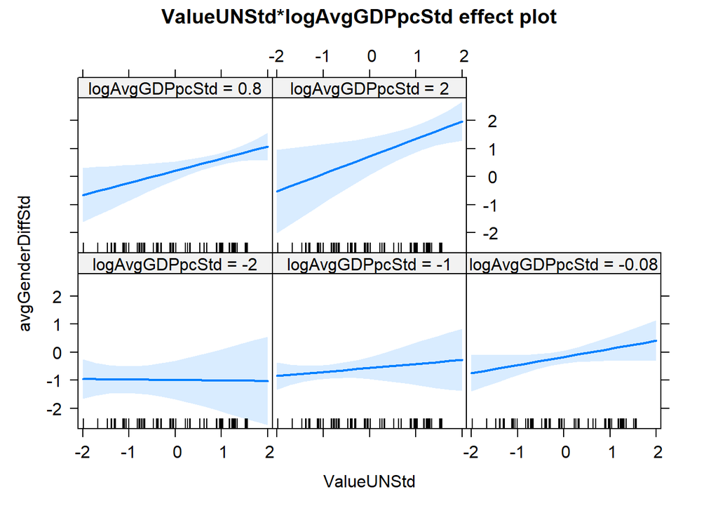

```r
plot(effect(term = "ValueUNStd:logAvgGDPpcStd", mod = lri4_b))
```

## Concluding Remarks

All the models are telling a similar story: The interaction effect between economic development and gender equality increases the gender differences with an estimation between 0.15 and 0.22 std dev. In all the cases, we see that at below-the-average to average economic development, the gender equality of the country doesn’t play a role (or it gives even a slight negative contribution) to the gender differences in economic preferences.

When the economic development starts to be above the average, we see that the contribution of the gender equality starts to become bigger and bigger (the slope is steeper with higher gender equality index).

Another interesting observation is that the models with interactions are more coherent to each other: the GDI gives now some statistically significant p-value as for the other ,odels, and all have a similar magnitude:

| Index used for Gender Equality | $\beta$ Economic Development | $\beta$ Gender Equality | $\beta$ Interaction Term |
| --- | --- | --- | --- |
| Gender Equality Index (GEI from original authors) | 0.47 | 0.34 | 0.20 |
| Gender Development Index (UNDP GDI) | 0.57 | 0.31 | 0.23 |
| Global Gender Gap Index (WEF GGGI) | 0.58 | 0.22 | 0.15 |
| Gender Inequality Index (UNDP GII) | 0.43 | 0.30 | 0.16 |

Note that the GII is inverted because originally it should be a measure of inequality, so multiplying it by a factor -1 should be the equality.

The economic development is still the variable playing the most important role, but now the gender equality is a statistically significant coefficient (at 10% level minimum) for all the models and with a coefficient being slightly less strong than economic development, while the interaction term is statistically significant at 10% level for all models, contributing in a smaller way but with similar magnitude as the other two coefficients (always less than a half wrt log GDP p/c).

# 2. Using Different Economic Development Indexes

## 2.1 Human Development Index

Now I want to explore a bit more the economic development index in a similar fashion as done for the gender equality. Let’s then try to use another estimator for the economic development of a country and, analogously as the GDI used for the gender equality measurement, I’ll use the Human Development Index (HDI) to capture a broader measure of the development for the countries analysed.

```r
# Read the input file
HDI <- fread("ExtendedAnalysis/files/input/HDR21-22_Composite_indices_complete_time_series.csv", sep = ",", nrows = 195)[, 1:37]

# Selecting the 2012 data similarly to the GDI
HDI <- HDI[, .(iso = iso3, country, hdi_2012)]

# Clean the country names according to the other data
HDI[country %like% "Bosnia and Herzegovina", country := "Bosnia Herzegovina"]
HDI[country %like% "Iran", country := "Iran"]
HDI[country %like% "Russian Federation", country := "Russia"]
HDI[country %like% "Korea", country := "South Korea"]
HDI[country %like% "Venezuela", country := "Venezuela"]
HDI[country %like% "Bolivia", country := "Bolivia"]
HDI[country %like% "Czechia", country := "Czech Republic"]
HDI[country %like% "Moldova", country := "Moldova"]
HDI[country %like% "Viet Nam", country := "Vietnam"]
HDI[country %like% "Tanzania", country := "Tanzania"]

data_all$HDI <- HDI

# Prepare summary index
summaryIndex[data_all$HDI, HDI := i.hdi_2012, on = "country"]

# Standardize the predictors (mean 0 and std dev 1)
summaryIndex <- Standardize(data    = summaryIndex,
                            columns = 24,
                            newName = TRUE)
```

### Relationship of HDI with Log GDP p/c and Gender Equality Indicators

After properly standardizing the data as done for the other variables, let’s understand the relationship of this new variable with respect to the gender equality indicators.

Of course, we see that the correlation with the Log GDP p/c is very high (95%) as expected, meaning that this indicator captures a similar insight for the countries. Nothing special, but always good to check.

```r
summary(lm(logAvgGDPpcStd ~ HDIStd, data = summaryIndex))
```

```
Call:
lm(formula = logAvgGDPpcStd ~ HDIStd, data = summaryIndex)

Residuals:
     Min       1Q   Median       3Q      Max
-0.73715 -0.20783  0.00512  0.23278  0.93450

Coefficients:
            Estimate Std. Error t value Pr(>|t|)
(Intercept) -0.01134    0.03753  -0.302    0.763
HDIStd       0.94837    0.03778  25.101   <2e-16 ***
---
Signif. codes:  0 '***' 0.001 '**' 0.01 '*' 0.05 '.' 0.1 ' ' 1

Residual standard error: 0.325 on 73 degrees of freedom
  (1 Beobachtung als fehlend gelöscht)
Multiple R-squared:  0.8962,    Adjusted R-squared:  0.8947
F-statistic: 630.1 on 1 and 73 DF,  p-value: < 2.2e-16
```

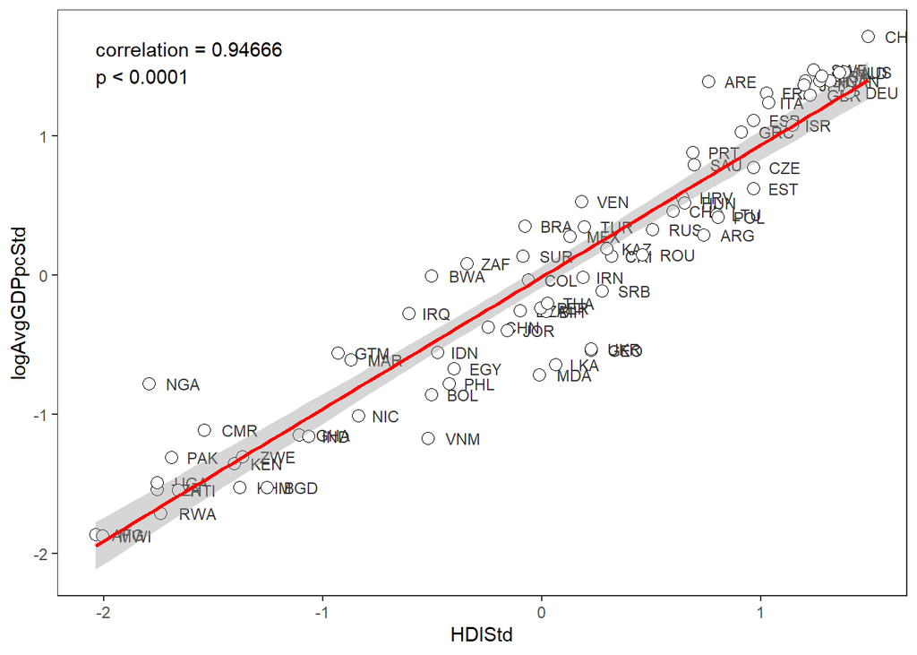

```r
PlotSummary(data = summaryIndex,
            var2 = "logAvgGDPpcStd", var1 = "HDIStd",
            display = TRUE)
```

```r
summary(lm(GenderIndexStd ~ HDIStd, data = summaryIndex))
```

```
Call:
lm(formula = GenderIndexStd ~ HDIStd, data = summaryIndex)

Residuals:
    Min      1Q  Median      3Q     Max
-2.1680 -0.3463  0.1359  0.5214  1.8310

Coefficients:
             Estimate Std. Error t value Pr(>|t|)
(Intercept) -0.001575   0.093839  -0.017    0.987
HDIStd       0.601508   0.094471   6.367 1.52e-08 ***
---
Signif. codes:  0 '***' 0.001 '**' 0.01 '*' 0.05 '.' 0.1 ' ' 1

Residual standard error: 0.8127 on 73 degrees of freedom
  (1 Beobachtung als fehlend gelöscht)
Multiple R-squared:  0.3571,    Adjusted R-squared:  0.3482
F-statistic: 40.54 on 1 and 73 DF,  p-value: 1.517e-08
```

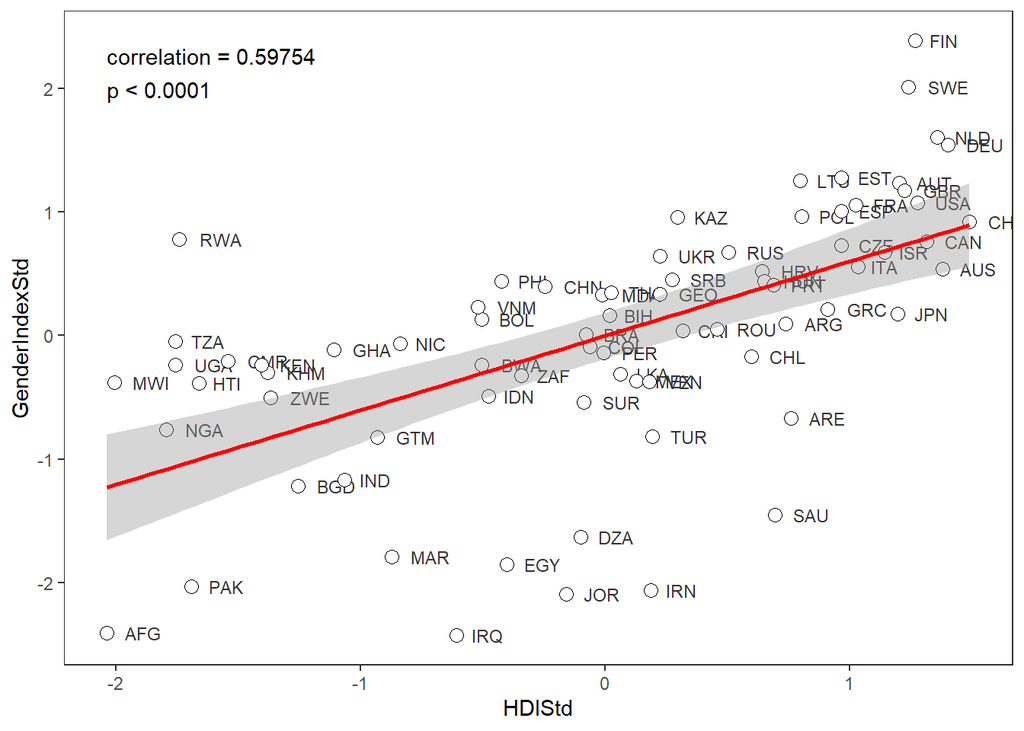

```r
PlotSummary(data = summaryIndex,
            var1 = "HDIStd", var2 = "GenderIndexStd",
            display = TRUE)
```

```r
summary(lm(GDIStd ~ HDIStd, data = summaryIndex))
```

```
Call:
lm(formula = GDIStd ~ HDIStd, data = summaryIndex)

Residuals:
    Min      1Q  Median      3Q     Max
-3.2026 -0.3586  0.0956  0.5875  1.1492

Coefficients:
            Estimate Std. Error t value Pr(>|t|)
(Intercept) 0.002204   0.092288   0.024    0.981
HDIStd      0.618863   0.092909   6.661  4.4e-09 ***
---
Signif. codes:  0 '***' 0.001 '**' 0.01 '*' 0.05 '.' 0.1 ' ' 1

Residual standard error: 0.7992 on 73 degrees of freedom
  (1 Beobachtung als fehlend gelöscht)
Multiple R-squared:  0.378, Adjusted R-squared:  0.3695
F-statistic: 44.37 on 1 and 73 DF,  p-value: 4.402e-09
```

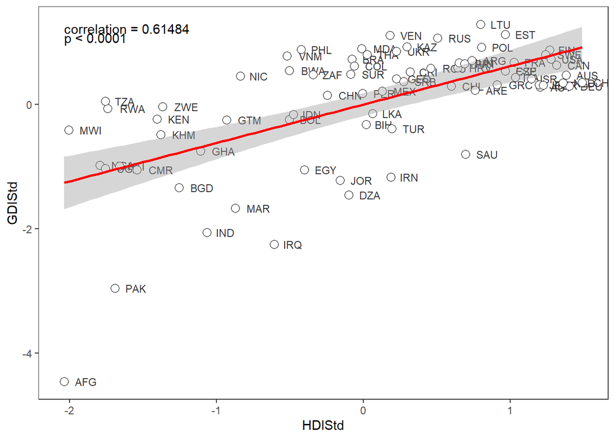

```r
PlotSummary(data = summaryIndex,
            var1 = "HDIStd", var2 = "GDIStd",
            display = TRUE)
```

```r
summary(lm(ScoreWEFStd ~ HDIStd, data = summaryIndex))
```

```
Call:
lm(formula = ScoreWEFStd ~ HDIStd, data = summaryIndex)

Residuals:
     Min       1Q   Median       3Q      Max
-2.30386 -0.34767  0.05393  0.53142  2.24423

Coefficients:
            Estimate Std. Error t value Pr(>|t|)
(Intercept) -0.00733    0.11288  -0.065  0.94842
HDIStd       0.34443    0.11646   2.958  0.00424 **
---
Signif. codes:  0 '***' 0.001 '**' 0.01 '*' 0.05 '.' 0.1 ' ' 1

Residual standard error: 0.9493 on 69 degrees of freedom
  (5 Beobachtungen als fehlend gelöscht)
Multiple R-squared:  0.1125,    Adjusted R-squared:  0.09964
F-statistic: 8.747 on 1 and 69 DF,  p-value: 0.004243
```

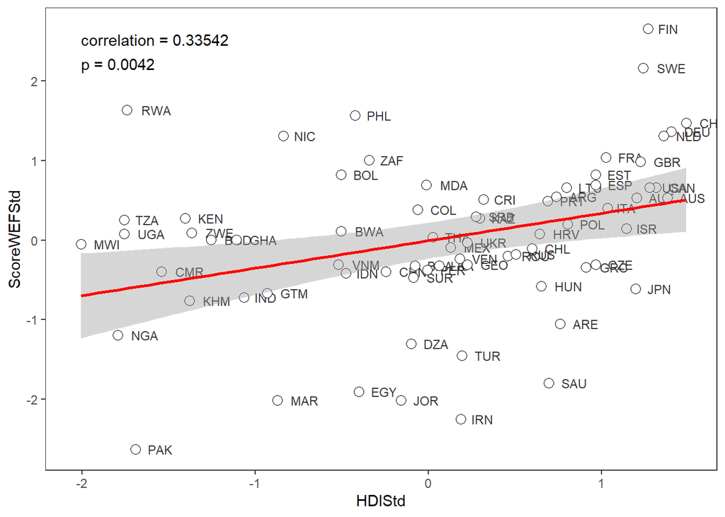

```r
PlotSummary(data = summaryIndex,
            var1 = "HDIStd", var2 = "ScoreWEFStd",
            display = TRUE)
```

```r
summary(lm(ValueUNStd ~ HDIStd, data = summaryIndex))
```

```
Call:
lm(formula = ValueUNStd ~ HDIStd, data = summaryIndex)

Residuals:
     Min       1Q   Median       3Q      Max
-1.18078 -0.27454 -0.03962  0.33924  1.23507

Coefficients:
            Estimate Std. Error t value Pr(>|t|)
(Intercept) -0.03993    0.05342  -0.748    0.457
HDIStd       0.89750    0.05462  16.432   <2e-16 ***
---
Signif. codes:  0 '***' 0.001 '**' 0.01 '*' 0.05 '.' 0.1 ' ' 1

Residual standard error: 0.4594 on 72 degrees of freedom
  (2 Beobachtungen als fehlend gelöscht)
Multiple R-squared:  0.7895,    Adjusted R-squared:  0.7865
F-statistic:   270 on 1 and 72 DF,  p-value: < 2.2e-16
```

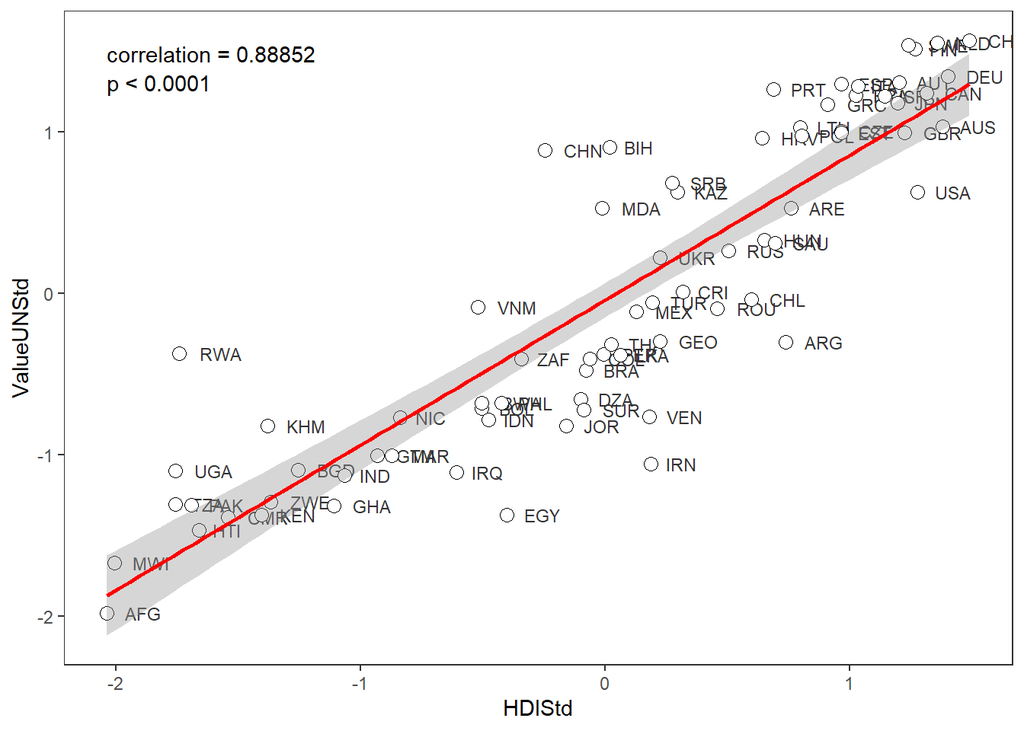

```r
PlotSummary(data = summaryIndex,
            var1 = "HDIStd", var2 = "ValueUNStd",
            display = TRUE)
```

### Modeling the effect of HDI and Gender Equality Indicators on gender differences on economic preferences

Now let’s create the models and analyse their outcome. I will not include the Gender Equality Index created by the original authors because in the past analysis it has already been widely criticized and the exclusion of it follows naturally.

```r
hdi_lri <- lm(avgGenderDiffStd ~ GDIStd * HDIStd,
           data = summaryIndex)
summary(hdi_lri)
```

```
Call:
lm(formula = avgGenderDiffStd ~ GDIStd * HDIStd, data = summaryIndex)

Residuals:
     Min       1Q   Median       3Q      Max
-1.20853 -0.57822 -0.03297  0.65111  1.39061

Coefficients:
              Estimate Std. Error t value Pr(>|t|)
(Intercept)   -0.12470    0.09927  -1.256   0.2132
GDIStd         0.21093    0.13735   1.536   0.1291
HDIStd         0.66739    0.10527   6.340 1.86e-08 ***
GDIStd:HDIStd  0.20555    0.09231   2.227   0.0291 *
---
Signif. codes:  0 '***' 0.001 '**' 0.01 '*' 0.05 '.' 0.1 ' ' 1

Residual standard error: 0.7065 on 71 degrees of freedom
  (1 Beobachtung als fehlend gelöscht)
Multiple R-squared:  0.5275,    Adjusted R-squared:  0.5075
F-statistic: 26.42 on 3 and 71 DF,  p-value: 1.383e-11
```

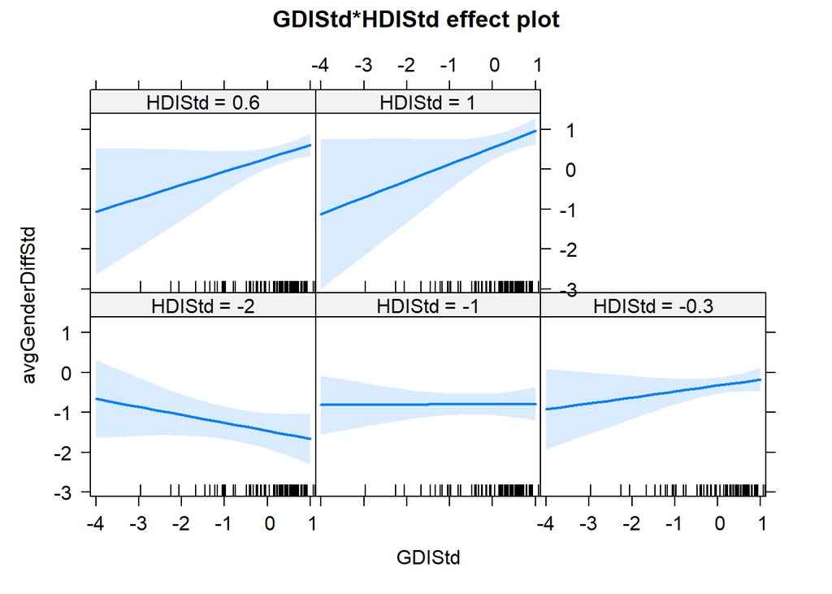

```r
plot(effect(term = "GDIStd:HDIStd", mod = hdi_lri))
```

```r
hdi_lri2 <- lm(avgGenderDiffStd ~ ScoreWEFStd * HDIStd,
            data = summaryIndex)
summary(hdi_lri2)
```

```
Call:
lm(formula = avgGenderDiffStd ~ ScoreWEFStd * HDIStd, data = summaryIndex)

Residuals:
     Min       1Q   Median       3Q      Max
-1.06302 -0.60882 -0.05922  0.60989  1.17518

Coefficients:
                   Estimate Std. Error t value Pr(>|t|)
(Intercept)        -0.03742    0.08394  -0.446   0.6572
ScoreWEFStd         0.19371    0.08551   2.265   0.0267 *
HDIStd              0.61738    0.08892   6.943 1.92e-09 ***
ScoreWEFStd:HDIStd  0.17809    0.07945   2.242   0.0283 *
---
Signif. codes:  0 '***' 0.001 '**' 0.01 '*' 0.05 '.' 0.1 ' ' 1

Residual standard error: 0.6743 on 67 degrees of freedom
  (5 Beobachtungen als fehlend gelöscht)
Multiple R-squared:  0.559, Adjusted R-squared:  0.5392
F-statistic: 28.31 on 3 and 67 DF,  p-value: 6.136e-12
```

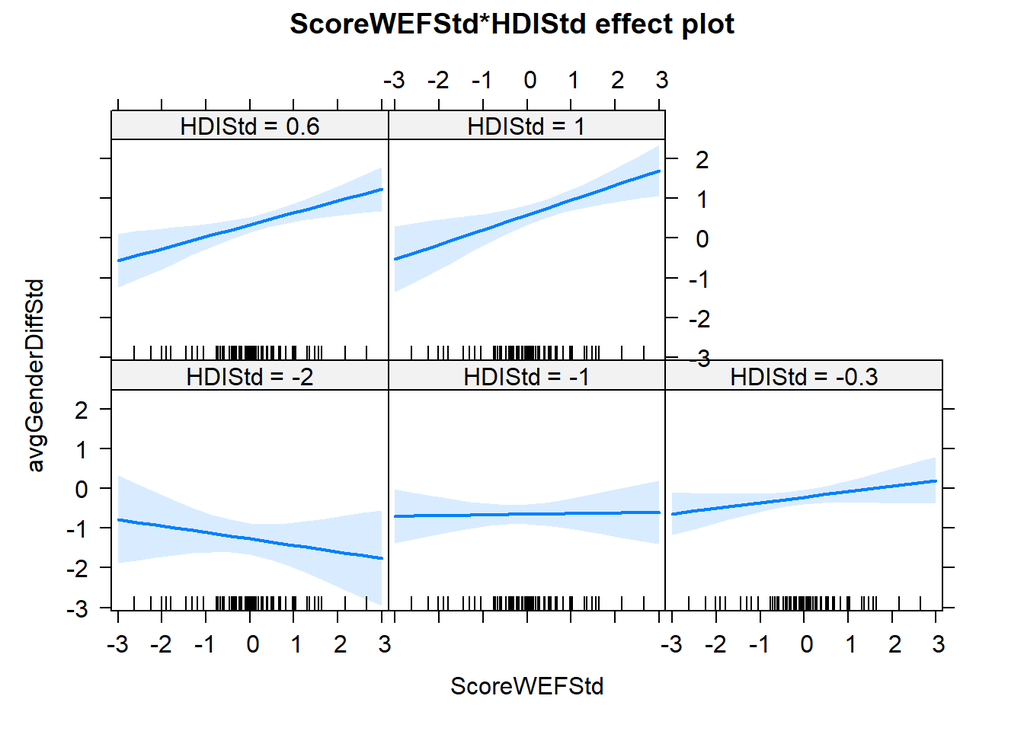

```r
plot(effect(term = "ScoreWEFStd:HDIStd", mod = hdi_lri2))
```

```r
hdi_lri3 <- lm(avgGenderDiffStd ~ ValueUNStd * HDIStd,
            data = summaryIndex)
summary(hdi_lri3)
```

```
Call:
lm(formula = avgGenderDiffStd ~ ValueUNStd * HDIStd, data = summaryIndex)

Residuals:
     Min       1Q   Median       3Q      Max
-1.35266 -0.47628 -0.06505  0.59702  1.47029

Coefficients:
                  Estimate Std. Error t value Pr(>|t|)
(Intercept)       -0.25559    0.11643  -2.195  0.03147 *
ValueUNStd         0.05403    0.18448   0.293  0.77050
HDIStd             0.74465    0.19172   3.884  0.00023 ***
ValueUNStd:HDIStd  0.28700    0.09604   2.988  0.00387 **
---
Signif. codes:  0 '***' 0.001 '**' 0.01 '*' 0.05 '.' 0.1 ' ' 1

Residual standard error: 0.679 on 70 degrees of freedom
  (2 Beobachtungen als fehlend gelöscht)
Multiple R-squared:  0.5684,    Adjusted R-squared:  0.5499
F-statistic: 30.73 on 3 and 70 DF,  p-value: 8.664e-13
```

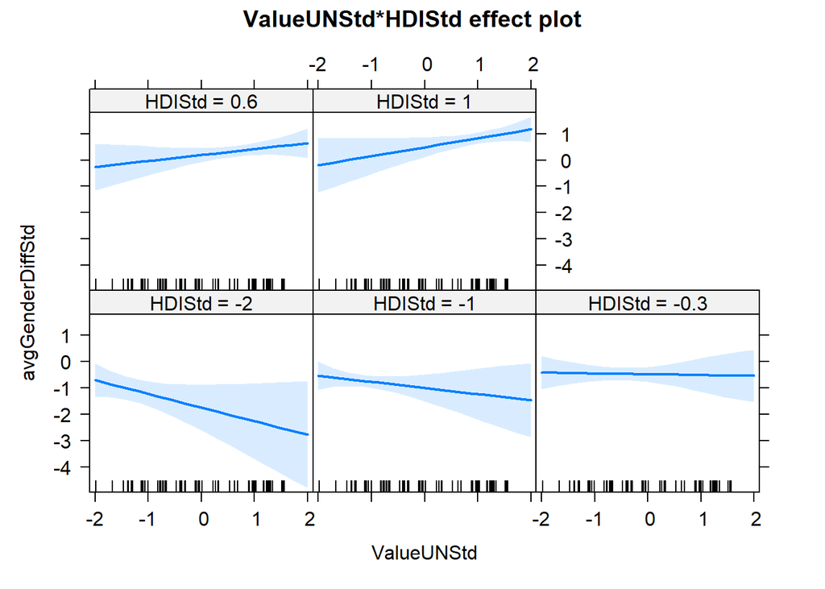

```r
plot(effect(term = "ValueUNStd:HDIStd", mod = hdi_lri3))
```

What does this imply? Do we have an effect due purely to the gender equality of the countries?

### Extra comment

What does it mean to model HDI together with GDI? GDI is the ratio between the HDI calculated for males on the one calculated for females.

## 2.2 Gross National Income p/c

```r
GNI <- fread("ExtendedAnalysis/files/input/API_NY.GNP.PCAP.PP.CD_DS2_en_csv_v2_4772085/API_NY.GNP.PCAP.PP.CD_DS2_en_csv_v2_4772085.csv", sep = ",", skip = 4, header = TRUE)

GNI <- GNI[, .(country = `Country Name`, isocode = `Country Code`, `2003`, `2004`, `2005`, `2006`, `2007`, `2008`, `2009`, `2010`, `2011`, `2012`)]

# Clean the country names according to the other data
GNI[country %like% "Bosnia and Herzegovina", country := "Bosnia Herzegovina"]
GNI[country %like% "Iran", country := "Iran"]
GNI[country %like% "Russian Federation", country := "Russia"]
GNI[country %like% "Korea", country := "South Korea"]
GNI[country %like% "Venezuela", country := "Venezuela"]
GNI[country %like% "Czechia", country := "Czech Republic"]
GNI[country %like% "Turkiye", country := "Turkey"]
GNI[country %like% "Egypt", country := "Egypt"]

avgGNI <- rowMeans(GNI[, -c("country", "isocode")], na.rm = TRUE)
GNI[, avgGNI := avgGNI]
data_all$GNI <- GNI

# Prepare summary index
summaryIndex[data_all$GNI, logAvgGNI := log(i.avgGNI), on = "country"]

# Standardize the predictors (mean 0 and std dev 1)
summaryIndex <- Standardize(data    = summaryIndex,
                            columns = 26,
                            newName = TRUE)
```

### Modeling the effect of Log GNI p/c and the gender equality indicators on the gender differences in economic preferences

```r
gni_lri <- lm(avgGenderDiffStd ~ GDIStd * logAvgGNIStd,
           data = summaryIndex)
summary(gni_lri)
```

```
Call:
lm(formula = avgGenderDiffStd ~ GDIStd * logAvgGNIStd, data = summaryIndex)

Residuals:
     Min       1Q   Median       3Q      Max
-1.89540 -0.59458  0.02349  0.57720  1.51004

Coefficients:
                    Estimate Std. Error t value Pr(>|t|)
(Intercept)         -0.13487    0.09988  -1.350  0.18119
GDIStd               0.37807    0.12257   3.084  0.00291 **
logAvgGNIStd         0.52362    0.09913   5.282 1.33e-06 ***
GDIStd:logAvgGNIStd  0.28529    0.10583   2.696  0.00876 **
---
Signif. codes:  0 '***' 0.001 '**' 0.01 '*' 0.05 '.' 0.1 ' ' 1

Residual standard error: 0.747 on 71 degrees of freedom
  (1 Beobachtung als fehlend gelöscht)
Multiple R-squared:  0.4717,    Adjusted R-squared:  0.4494
F-statistic: 21.13 on 3 and 71 DF,  p-value: 6.887e-10
```

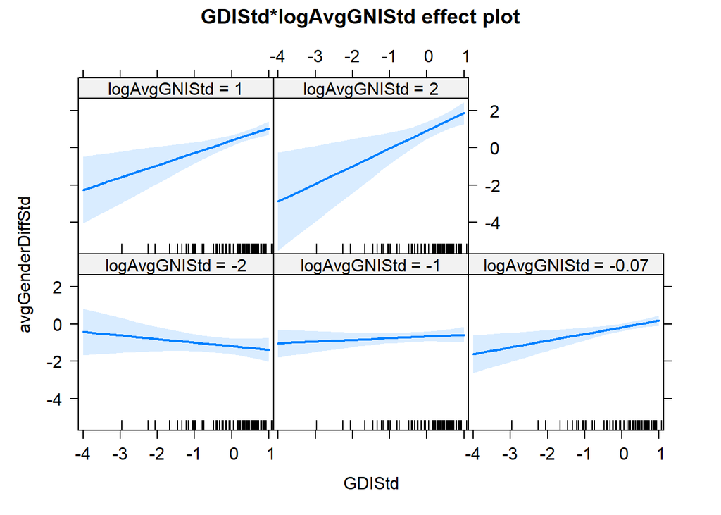

```r
plot(effect(term = "GDIStd:logAvgGNIStd", mod = gni_lri))
```

```r
gni_lri2 <- lm(avgGenderDiffStd ~ ScoreWEFStd * logAvgGNIStd,
           data = summaryIndex)
summary(gni_lri2)
```

```
Call:
lm(formula = avgGenderDiffStd ~ ScoreWEFStd * logAvgGNIStd, data = summaryIndex)

Residuals:
     Min       1Q   Median       3Q      Max
-1.19222 -0.56634 -0.07951  0.60579  1.25575

Coefficients:
                           Estimate Std. Error t value Pr(>|t|)
(Intercept)              -0.0009196  0.0855902  -0.011  0.99146
ScoreWEFStd               0.2686640  0.0874019   3.074  0.00306 **
logAvgGNIStd              0.5386633  0.0887862   6.067 6.78e-08 ***
ScoreWEFStd:logAvgGNIStd  0.1697270  0.0848460   2.000  0.04951 *
---
Signif. codes:  0 '***' 0.001 '**' 0.01 '*' 0.05 '.' 0.1 ' ' 1

Residual standard error: 0.7092 on 67 degrees of freedom
  (5 Beobachtungen als fehlend gelöscht)
Multiple R-squared:  0.5121,    Adjusted R-squared:  0.4903
F-statistic: 23.44 on 3 and 67 DF,  p-value: 1.731e-10
```

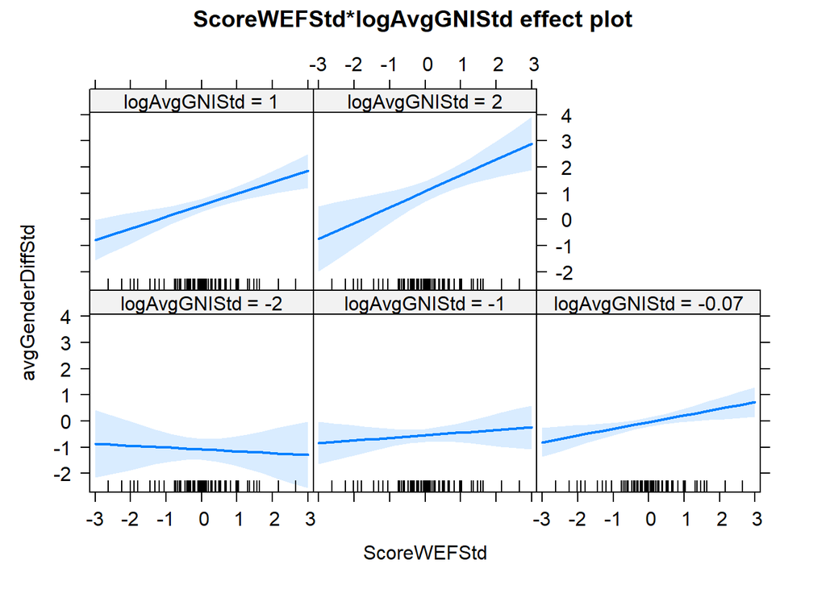

```r
plot(effect(term = "ScoreWEFStd:logAvgGNIStd", mod = gni_lri2))
```

```r
gni_lri3 <- lm(avgGenderDiffStd ~ ValueUNStd * logAvgGNIStd,
           data = summaryIndex)
summary(gni_lri3)
```

```
Call:
lm(formula = avgGenderDiffStd ~ ValueUNStd * logAvgGNIStd, data = summaryIndex)

Residuals:
     Min       1Q   Median       3Q      Max
-1.65941 -0.52206  0.00093  0.50860  1.50470

Coefficients:
                        Estimate Std. Error t value Pr(>|t|)
(Intercept)             -0.14923    0.11618  -1.285  0.20320
ValueUNStd               0.45271    0.14938   3.031  0.00342 **
logAvgGNIStd             0.29935    0.15086   1.984  0.05114 .
ValueUNStd:logAvgGNIStd  0.20206    0.09868   2.048  0.04436 *
---
Signif. codes:  0 '***' 0.001 '**' 0.01 '*' 0.05 '.' 0.1 ' ' 1

Residual standard error: 0.7265 on 70 degrees of freedom
  (2 Beobachtungen als fehlend gelöscht)
Multiple R-squared:  0.5059,    Adjusted R-squared:  0.4847
F-statistic: 23.89 on 3 and 70 DF,  p-value: 9.342e-11
```

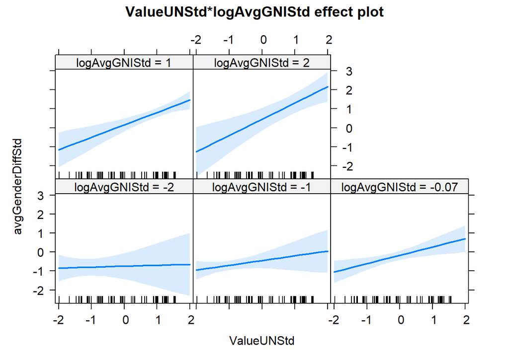

```r
plot(effect(term = "ValueUNStd:logAvgGNIStd", mod = gni_lri3))
```

```r
summary(lm(ValueUNStd ~ logAvgGNIStd, data = summaryIndex))
```

```
Call:
lm(formula = ValueUNStd ~ logAvgGNIStd, data = summaryIndex)

Residuals:
     Min       1Q   Median       3Q      Max
-1.36949 -0.43331  0.00416  0.43960  1.41704

Coefficients:
             Estimate Std. Error t value Pr(>|t|)
(Intercept)  -0.02901    0.06783  -0.428     0.67
logAvgGNIStd  0.80803    0.06828  11.833   <2e-16 ***
---
Signif. codes:  0 '***' 0.001 '**' 0.01 '*' 0.05 '.' 0.1 ' ' 1

Residual standard error: 0.5834 on 72 degrees of freedom
  (2 Beobachtungen als fehlend gelöscht)
Multiple R-squared:  0.6604,    Adjusted R-squared:  0.6557
F-statistic:   140 on 1 and 72 DF,  p-value: < 2.2e-16
```

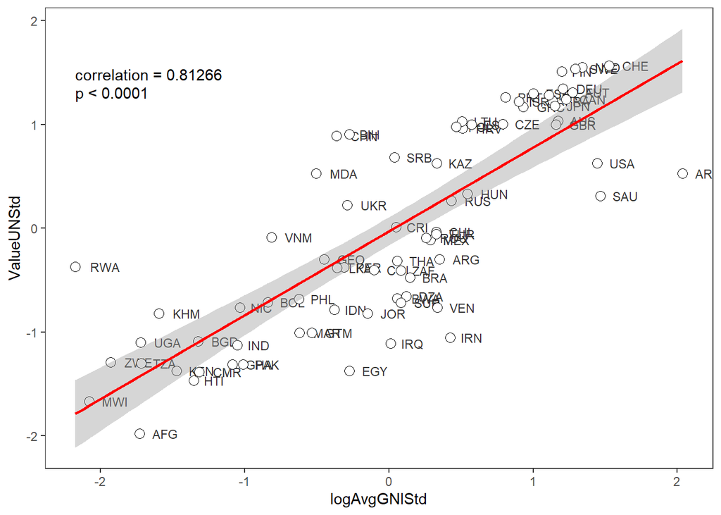

```r
PlotSummary(data = summaryIndex,
            var1 = "logAvgGNIStd", var2 = "ValueUNStd",
            display = TRUE)
```

I am very puzzled by this result. Basically, using the UNDP GII together with the HDI as economic development, the coefficient for the gender equality index is not statistically significant (and close to 0). On the other side, if we use the log GNI (which is part of the HDI), the statistical significance appears for the gender equality and, on the contrary, it disappears for the economic development part. Hard to believe it is a random oscillation because the p-value and the coefficient of the economic development has been always very strong for all the other models.